# MEDL_HW3_v4

**Deep Learning for Mechanical Engineering**  
**Homework 03**  
**Due Thursday, 05/16/2019, 3:30 PM**

By Prof. Seungchul Lee  
http://iai.postech.ac.kr/  
Industrial AI Lab at POSTECH

- For your handwritten solution, hand in your hardcopy before the class begins.
- For your code, email your .ipynb file to iai.postech@gmail.com. Only .ipynb file will be graded.
- When you send an e-mail, you **must write down [Deep Learning Homework] on the title**.
- And please write your NAME on your .ipynb files. ex) 김승욱_20192319 _HW1.ipynb
- Do not submit a printed version of your code. It will not be graded.
- If you have any questions on the homework problems, please email our TA via iai.postech@gmail.com.

# Problem 1

We did CNN classifiction in last homework for this 'Happy house' dataset. This time, we want to know what is the key feature(or pixel) to classify the picture as either happy or not. As we learned in class, apply CAM algorithm to this dataset.

Take pictures of your friends and yourself, and test them on your model.

Download Happy house data from :

- [expression_train_img](https://www.dropbox.com/s/cfxd9pjtrqdrx2c/expression_train_img.pkl?dl=1)
- [expression_train_label](https://www.dropbox.com/s/42s2vdh2jym2x9g/expression_train_label.pkl?dl=1)
- [expression_test_img](https://www.dropbox.com/s/iu24mros7avmxq1/expression_test_img.pkl?dl=1)
- [expression_test_label](https://www.dropbox.com/s/nweuwj3cx4zrwa6/expression_test_label.pkl?dl=1)

```python
import tensorflow as tf
import numpy as np
import matplotlib.pyplot as plt
from six.moves import cPickle
import cv2
```

It is now time to solve the "Happy" Challenge.

```python
train_x_total = cPickle.load(open('./data_files/expression_train_img.pkl','rb'))
train_y_total = cPickle.load(open('./data_files/expression_train_label.pkl', 'rb'))
```

```python
test_x_total = cPickle.load(open('./data_files/expression_test_img.pkl', 'rb'))
test_y_total = cPickle.load(open('./data_files/expression_test_label.pkl', 'rb'))
```

Define CAM model and train it.

```
Iter : 0
Cost : 1.2529939413070679
Iter : 250
Cost : 0.6810305714607239
Iter : 500
Cost : 0.652850866317749
Iter : 750
Cost : 0.6380239725112915
Iter : 1000
Cost : 0.6965438723564148
Iter : 1250
Cost : 0.6405428051948547
Iter : 1500
Cost : 0.6107884049415588
Iter : 1750
Cost : 0.6488277912139893
Iter : 2000
Cost : 0.6240090727806091
Iter : 2250
Cost : 0.5798419713973999
Iter : 2500
Cost : 0.6027246117591858
Iter : 2750
Cost : 0.5966057181358337
Iter : 3000
Cost : 0.5472464561462402
Iter : 3250
Cost : 0.5341371893882751
Iter : 3500
Cost : 0.540581226348877
Iter : 3750
Cost : 0.6130752563476562
Iter : 4000
Cost : 0.530933678150177
Iter : 4250
Cost : 0.5680026412010193
Iter : 4500
Cost : 0.5141085982322693
Iter : 4750
Cost : 0.45821988582611084
```

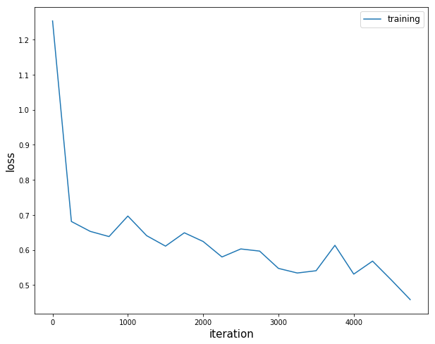

```python
# your code here
```

Test/evaluate your CAM model.

```python
# your code here
```

```
Accuracy : 78.0%
```

Plot your activation map and test image(happy house image)

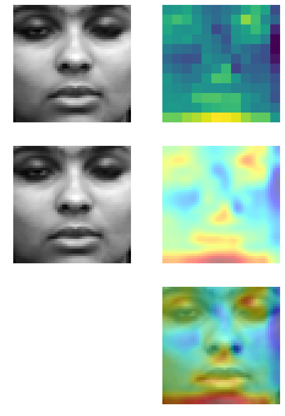

```python
# your code here
```

Test CAM algorithm with your own picture.

```python
# your code here
```

# Problem 2

We studied FCN model with VGG16 network in class. Implement your FCN model using VGG19 network for encoder part of the model and test it. I recommend you use colab rather than your laptop.

Download data from [here](https://www.dropbox.com/s/24okrd00jfj5qot/FCN_lecture_data_files.zip?dl=1)

```python
# import library

import keras
import numpy as np
import matplotlib.pyplot as plt
import tensorflow as tf
import scipy
```

Load segmented data.

```python
# your code here
```

```
The number of training images : 289, shape : (289, 160, 576, 3)
The number of testing images : 290, shape : (290, 160, 576, 3)
```

Plot random image of train data set.

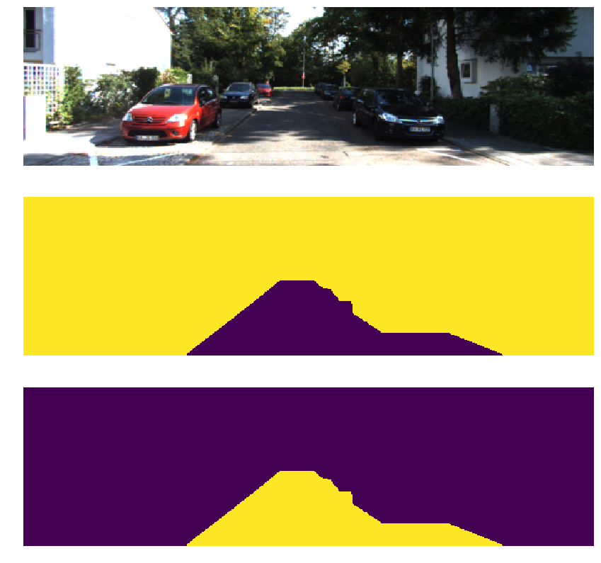

```python
# your code here
```

Load VGG19 network.

```python
# your code here
```

```
Downloading data from https://github.com/fchollet/deep-learning-models/releases/download/v0.1/vgg19_weights_tf_dim_ordering_tf_kernels.h5
_________________________________________________________________
Layer (type)                 Output Shape              Param #
=================================================================
input_1 (InputLayer)         (None, 224, 224, 3)       0
_________________________________________________________________
block1_conv1 (Conv2D)        (None, 224, 224, 64)      1792
_________________________________________________________________
block1_conv2 (Conv2D)        (None, 224, 224, 64)      36928
_________________________________________________________________
block1_pool (MaxPooling2D)   (None, 112, 112, 64)      0
_________________________________________________________________
block2_conv1 (Conv2D)        (None, 112, 112, 128)     73856
_________________________________________________________________
block2_conv2 (Conv2D)        (None, 112, 112, 128)     147584
_________________________________________________________________
block2_pool (MaxPooling2D)   (None, 56, 56, 128)       0
_________________________________________________________________
block3_conv1 (Conv2D)        (None, 56, 56, 256)       295168
_________________________________________________________________
block3_conv2 (Conv2D)        (None, 56, 56, 256)       590080
_________________________________________________________________
block3_conv3 (Conv2D)        (None, 56, 56, 256)       590080
_________________________________________________________________
block3_conv4 (Conv2D)        (None, 56, 56, 256)       590080
_________________________________________________________________
block3_pool (MaxPooling2D)   (None, 28, 28, 256)       0
_________________________________________________________________
block4_conv1 (Conv2D)        (None, 28, 28, 512)       1180160
_________________________________________________________________
block4_conv2 (Conv2D)        (None, 28, 28, 512)       2359808
_________________________________________________________________
block4_conv3 (Conv2D)        (None, 28, 28, 512)       2359808
_________________________________________________________________
block4_conv4 (Conv2D)        (None, 28, 28, 512)       2359808
_________________________________________________________________
block4_pool (MaxPooling2D)   (None, 14, 14, 512)       0
_________________________________________________________________
block5_conv1 (Conv2D)        (None, 14, 14, 512)       2359808
_________________________________________________________________
block5_conv2 (Conv2D)        (None, 14, 14, 512)       2359808
_________________________________________________________________
block5_conv3 (Conv2D)        (None, 14, 14, 512)       2359808
_________________________________________________________________
block5_conv4 (Conv2D)        (None, 14, 14, 512)       2359808
_________________________________________________________________
block5_pool (MaxPooling2D)   (None, 7, 7, 512)         0
_________________________________________________________________
flatten (Flatten)            (None, 25088)             0
_________________________________________________________________
fc1 (Dense)                  (None, 4096)              102764544
_________________________________________________________________
fc2 (Dense)                  (None, 4096)              16781312
_________________________________________________________________
predictions (Dense)          (None, 1000)              4097000
=================================================================
Total params: 143,667,240
Trainable params: 143,667,240
Non-trainable params: 0
_________________________________________________________________
```

Check the weights of VGG19 network for each layer.

```python
# load vgg19 model
# your code here
```

```python
# your code here
```

```
(3, 3, 3, 64)
(64,)
(3, 3, 64, 64)
(64,)
(3, 3, 64, 128)
(128,)
(3, 3, 128, 128)
(128,)
(3, 3, 128, 256)
(256,)
(3, 3, 256, 256)
(256,)
(3, 3, 256, 256)
(256,)
(3, 3, 256, 256)
(256,)
(3, 3, 256, 512)
(512,)
(3, 3, 512, 512)
(512,)
(3, 3, 512, 512)
(512,)
(3, 3, 512, 512)
(512,)
(3, 3, 512, 512)
(512,)
(3, 3, 512, 512)
(512,)
(3, 3, 512, 512)
(512,)
(3, 3, 512, 512)
(512,)
(25088, 4096)
(4096,)
(4096, 4096)
(4096,)
(4096, 1000)
(1000,)
```

Define weights, biases, and placeholders. Use the pre trained weights of VGG19 network except fullyconnected layers.

```python
# your code here
```

Define FCN model.

```python
# define FCN model
# your code here
```

```python
# define loss and optimizer
# your code here
```

```python
# define train batch maker
# your code here
```

```python
# define test batch maker
# your code here
```

Train the model.

```
Epoch : 0
Cost : 3.7945988178253174
Epoch : 30
Cost : 0.2555178999900818
Epoch : 60
Cost : 0.14156241714954376
Epoch : 90
Cost : 0.12448029965162277
Epoch : 120
Cost : 0.1060006320476532
Epoch : 150
Cost : 0.11434876918792725
Epoch : 180
Cost : 0.09275802969932556
Epoch : 210
Cost : 0.0959756150841713
Epoch : 240
Cost : 0.06538790464401245
Epoch : 270
Cost : 0.07235682010650635
```

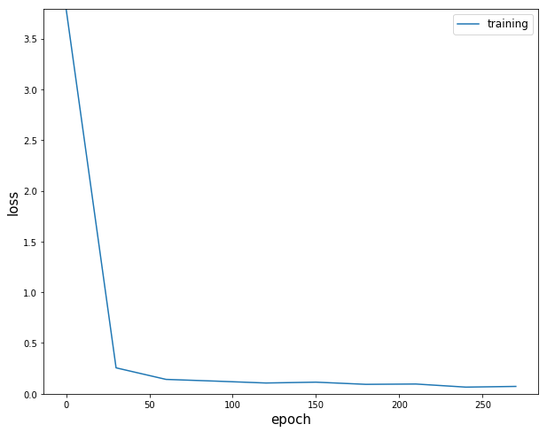

```python
# your code here
```

Test the model.

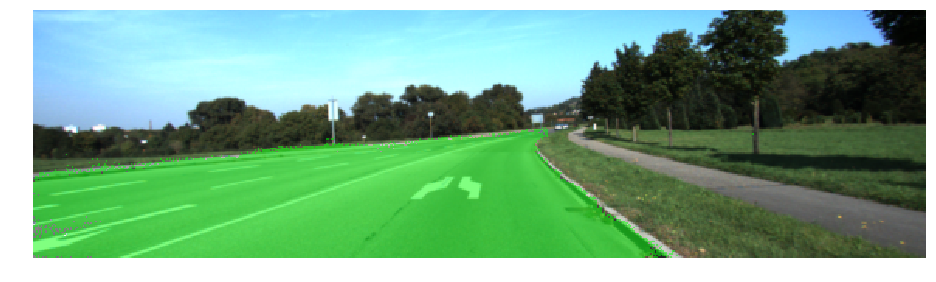

```python
# your code here
```

Discuss what if we use input image that has larger size than this dataset.